# P3

### Universidad de Costa Rica

#### IE0405 - Modelos Probabilísticos de Señales y Sistemas

Primer semestre del 2022

- Estudiante: **Isaí David Vargas Ovares**
- Carné: **B88263**
- Grupo: **2**

# `P3` - *Manipulación y modelado de datos*

**Nota**: Es recomendable revisar los tutoriales `Py0`, `Py1`, `Py2`, `Py3` (**Pandas**), `Py4` (**scipy.stats**) y `Py5` (**Fitter**) (disponibles [aquí](https://github.com/fabianabarca/mpss)) para conocer las bases de Python útiles en la ejecución de este laboratorio.

## P3.1 - Adquisición de datos con Pandas

### Conjunto de datos de mediciones de árboles

Para este laboratorio utilizaremos un documento con el nombre, el diámetro, la altura y otros datos de una serie de árboles que fueron estudiados a la largo de una carretera nacional. Está disponible en el archivo `arboles.csv`.

```python
import pandas as pd

# Importar CSV en DataFrame
arboles = pd.read_csv('arboles.csv')

# Mostrar primeros datos
arboles.head()
```

|  | Secuencia | Nombre común | Diámetro (cm) | Altura total (m) | Altura comercial (m) | Volumen comercial (m3) | Valor comercial aproximado (CRC) |
| --- | --- | --- | --- | --- | --- | --- | --- |
| 0 | I0001 | roble sabana | 64.6 | 12.0 | 6.0 | 1.0 | 31323.29 |
| 1 | I0002 | roble sabana | 56.0 | 10.0 | 4.0 | 0.0 | 15692.32 |
| 2 | I0003 | jocote | 32.0 | 4.0 | 2.0 | 0.0 | 0.00 |
| 3 | I0004 | cenízaro | 72.4 | 13.0 | 4.0 | 1.0 | 54545.22 |
| 4 | I0005 | guayaquil | 55.3 | 11.0 | 6.0 | 1.0 | 19301.97 |

```python
# Breve escripción estadística
arboles.describe()
```

|  | Diámetro (cm) | Altura total (m) | Altura comercial (m) | Volumen comercial (m3) | Valor comercial aproximado (CRC) |
| --- | --- | --- | --- | --- | --- |
| count | 10681.000000 | 10681.000000 | 8850.000000 | 10681.000000 | 1.068100e+04 |
| mean | 33.363187 | 9.548825 | 2.627989 | 0.132063 | 9.352564e+03 |
| std | 21.485462 | 3.812823 | 1.516758 | 0.595048 | 3.764279e+04 |
| min | 15.000000 | 1.500000 | 0.000000 | 0.000000 | 0.000000e+00 |
| 25% | 20.000000 | 7.000000 | 1.500000 | 0.000000 | 0.000000e+00 |
| 50% | 26.400000 | 8.000000 | 2.000000 | 0.000000 | 1.133880e+03 |
| 75% | 38.600000 | 12.000000 | 3.000000 | 0.000000 | 4.193840e+03 |
| max | 292.000000 | 25.000000 | 15.000000 | 18.000000 | 1.290347e+06 |

### P3.2. Análisis estadístico

- (20 %) **Ejercicio 1**: Determine la cantidad de especies distintas de árboles y lístelas.

```python
# Ejercicio 1
#Crea una lista con los nombres sin repetir o unicos de la columna de nombre de los arboles
lista=arboles['Nombre común'].unique().tolist()

#Lee el tamano de la lista anterior, asi se determina la cantidad de especies
cantidad=len(lista)

#Se imprime la cantidad y la lista obtenida
print("La cantidad de especies distintas de árboles es:"+str(cantidad))
print("Lista de especies:",lista)
```

[output not shown]

- (50 %) **Ejercicio 2**: Grafique el histograma de la distribución del diámetro de todos los árboles y determine los parámetros del modelo de mejor ajuste para los datos dados, y grafique la curva junto con el histograma.

```
count    10681.000000
mean        33.363187
std         21.485462
min         15.000000
25%         20.000000
50%         26.400000
75%         38.600000
max        292.000000
Name: Diámetro (cm), dtype: float64
---------------------
Parametros del ajuste
Distribución:   gamma
Dominio:        [0.0, inf]
Parámetros:     (nan, nan, 1.0)
```

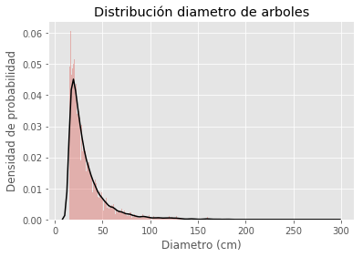

```python
#Se importan las librerias necesarias
import pandas as pd
import numpy as np
import seaborn as sns
import matplotlib.pyplot as plt
from scipy import stats

#Se toman los datos con los que se va a trabajar
datos = arboles['Diámetro (cm)']
#Se imprimen algunos datos de utilidad
print(datos.describe())


# Ajuste distribución
#Se define el tipo de distribución
distribucion = stats.gamma

#Con el método fit() se obtienen los parámetros
parametros = distribucion.fit(data=datos)

#Gráfico
#Se crea el histograma de distribucion y se utiliza Kde para mostrar la curva de ajuste
g=sns.distplot(datos,bins=300,kde=True,kde_kws={"color": "k"})
#Se le da nombre al titulo y ejes
g.set_title('Distribución diametro de arboles')
g.set_xlabel('Diametro (cm)')
g.set_ylabel('Densidad de probabilidad')


#Información del ajuste
print('---------------------')
print('Parametros del ajuste')
print(f"Distribución:   {distribucion.name}")
print(f"Dominio:        {[distribucion.a, distribucion.b]}")
print(f"Parámetros:     {parametros}")
```

- (30 %) **Ejercicio 3**: Determine cuál es la especie de árbol con mayor valor comercial promedio.

```python
# Ejercicio 3
#Se agrupan todos los arboles con el mismo nombre y se calcula su media
df=arboles.groupby('Nombre común').mean()

#Se obtiene el arbol con el valor mas alto en la columna de valor comercial
Arbol=df['Valor comercial aproximado (CRC)'].idxmax()
#Se imprime el nombre del arbol obtenido
print("El arbol con mayor valor comercial promedio es: ", Arbol)
```

```
El arbol con mayor valor comercial promedio es:  guanacaste
```

**Forma de entrega**

**Nota 1**: No olvide los comentarios para explicar cada paso y procure orden en el código.

**Nota 2**: En el curso nos apegamos al [PEP 8](https://www.python.org/dev/peps/pep-0008/) - *Style Guide for Python Code*, que procura consistencia y claridad en la forma de escribir.

Recuerde convertir este archivo con su *solución comentada* para entregarlo en formato HTML (para visualizar en web), en **File > Download as > HTML (.html)** y ponerle el nombre `[carné].html` (ejemplo: B12345.html).

**Universidad de Costa Rica** | Facultad de Ingeniería | Escuela de Ingeniería Eléctrica

© 2022